# examples_0326

A turtle starts at the star in the middle, facing North. She walks forward for a while, then turns 60° either to her right (clockwise) or to her left (counterclockwise). She repeats this, marking her path with various colors, until she has drawn 6 segments.

The distance between adjacent dots is 1 unit.

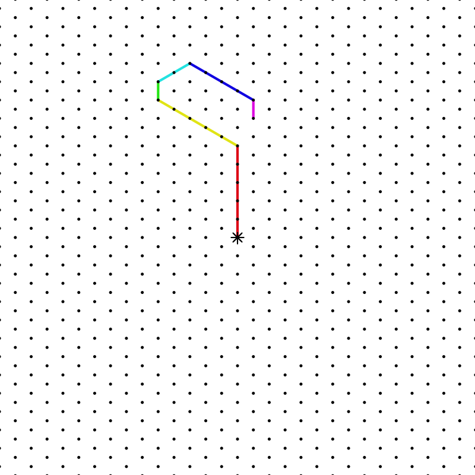

Describe the path taken by the turtle.

- Go
- Turn
- Go
- Turn
- Go
- Turn
- Go
- Turn
- Go
- Turn
- Go
- Go 5
- Turn left
- Go 5
- Turn right
- Go 1
- Turn right
- Go 2
- Turn right
- Go 4
- Turn right
- Go 1

Let's say you want to make a [spirolateral](https://en.wikipedia.org/wiki/Spirolateral).

If the turn angle is $\theta=135^{\circ}$ and the maximum segment length is $n=5$, then which spirolateral is created?

You can use this tool:

https://artockthedino.github.io/pbl/spirolateral/spirolateral_generator.html

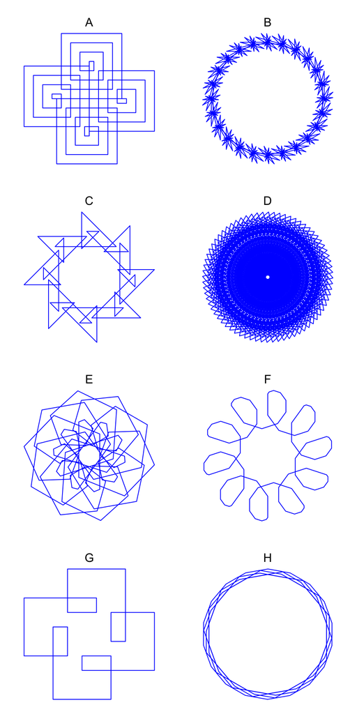

ABCDEFGH

The correct answer is C.

Below I've listed the parameters used to generate all patterns:

- A:
  - Turn angle = 90
  - Count max = 15

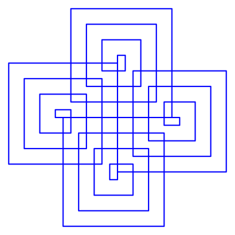

- B:
  - Turn angle = 165
  - Count max = 13

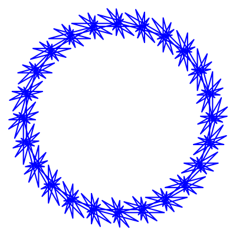

- C:
  - Turn angle = 135
  - Count max = 5

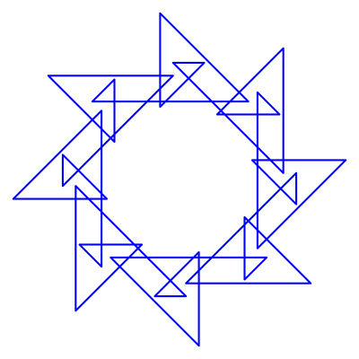

- D:
  - Turn angle = 115
  - Count max = 17

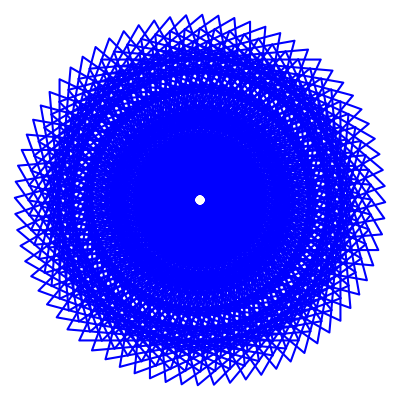

- E:
  - Turn angle = 68
  - Count max = 9

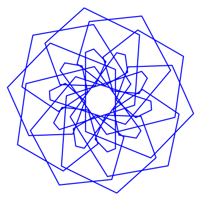

- F:
  - Turn angle = 36
  - Count max = 9

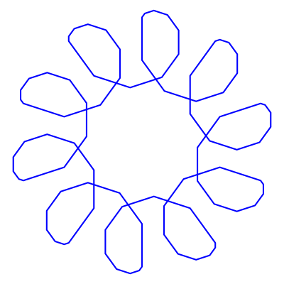

- G:
  - Turn angle = 90
  - Count max = 5

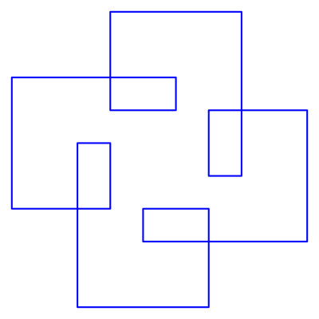

- H:
  - Turn angle = 20
  - Count max = 5

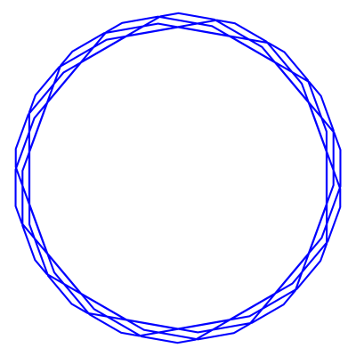

Let's say you want to make a [spirolateral](https://en.wikipedia.org/wiki/Spirolateral).

If the turn angle is $\theta=45^{\circ}$ and the maximum segment length is $n=17$, then which spirolateral is created?

You can use this tool:

https://artockthedino.github.io/pbl/spirolateral/spirolateral_generator.html

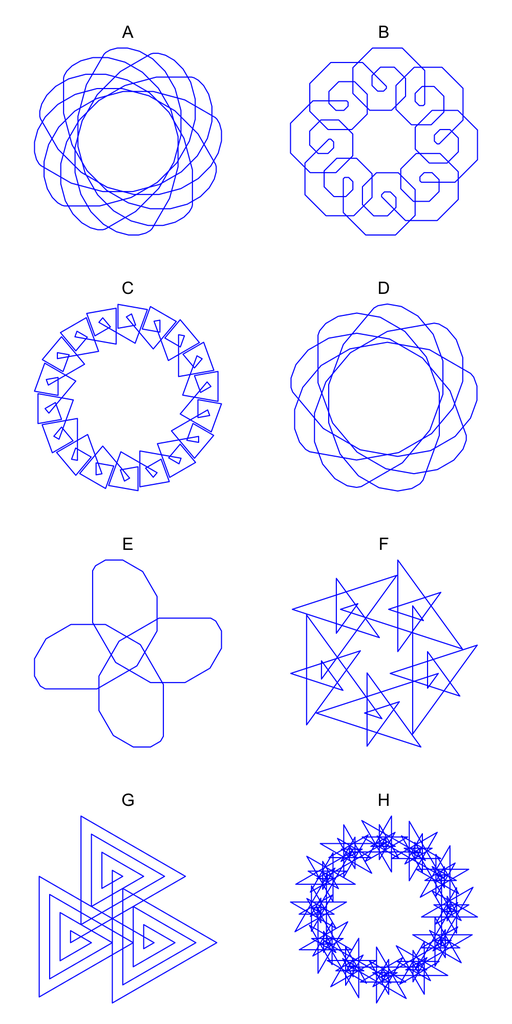

ABCDEFGH

The correct answer is B.

Below I've listed the parameters used to generate all patterns:

- A:
  - Turn angle = 15
  - Count max = 14

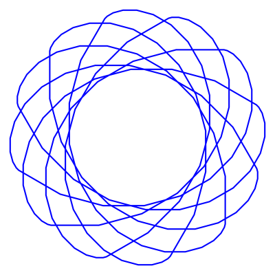

- B:
  - Turn angle = 45
  - Count max = 17

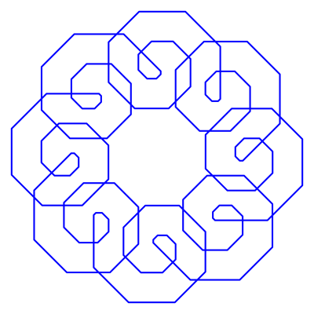

- C:
  - Turn angle = 100
  - Count max = 7

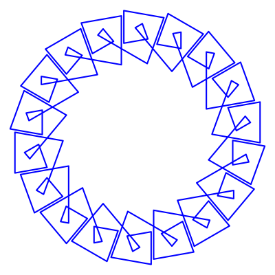

- D:
  - Turn angle = 20
  - Count max = 10

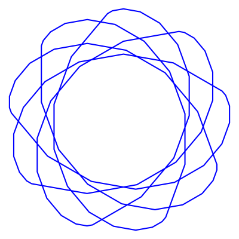

- E:
  - Turn angle = 30
  - Count max = 9

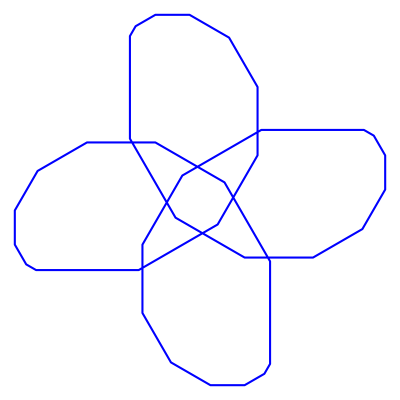

- F:
  - Turn angle = 144
  - Count max = 7

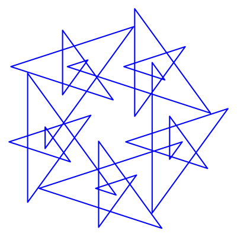

- G:
  - Turn angle = 120
  - Count max = 11

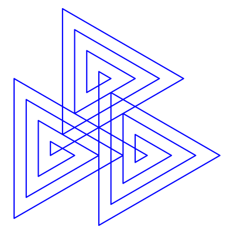

- H:
  - Turn angle = 150
  - Count max = 19

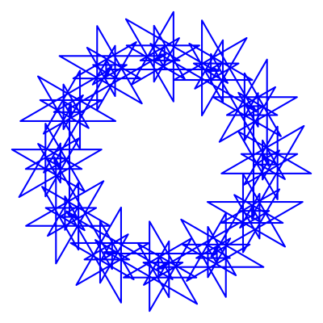

Let's say you want to make a [spirolateral](https://en.wikipedia.org/wiki/Spirolateral).

If the turn angle is $\theta=10^{\circ}$ and the maximum segment length is $n=12$, then which spirolateral is created?

You can use this tool:

https://artockthedino.github.io/pbl/spirolateral/spirolateral_generator.html

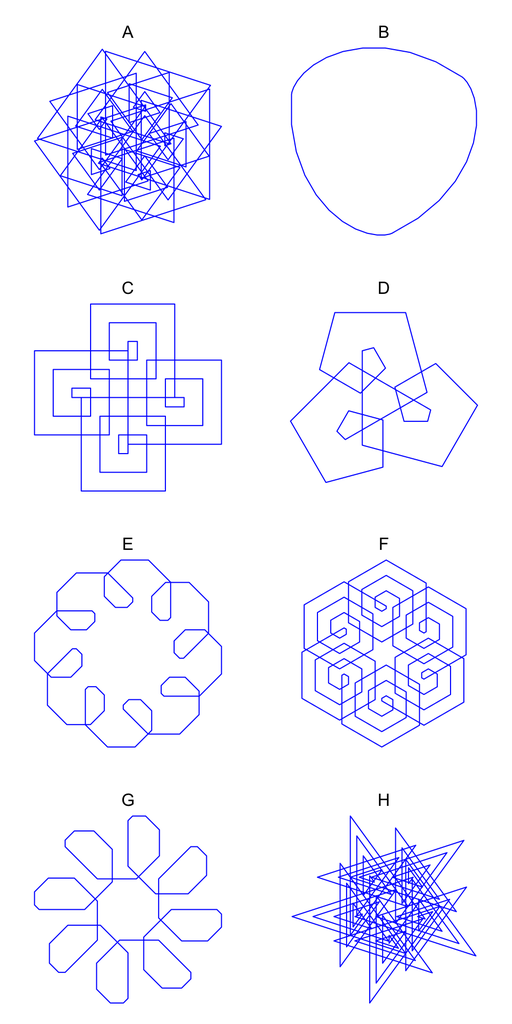

ABCDEFGH

The correct answer is B.

Below I've listed the parameters used to generate all patterns:

- A:
  - Turn angle = 108
  - Count max = 18

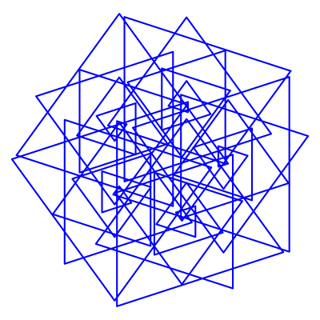

- B:
  - Turn angle = 10
  - Count max = 12

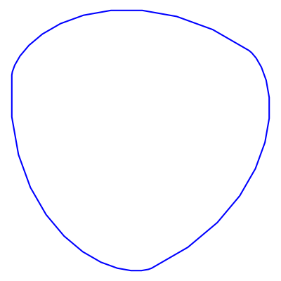

- C:
  - Turn angle = 90
  - Count max = 11

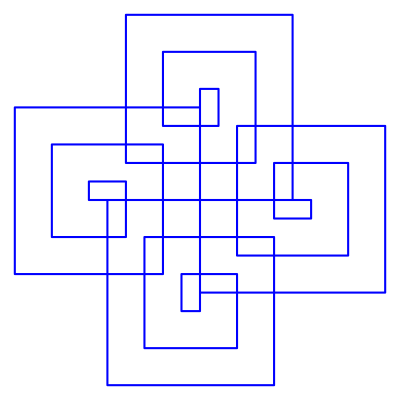

- D:
  - Turn angle = 75
  - Count max = 8

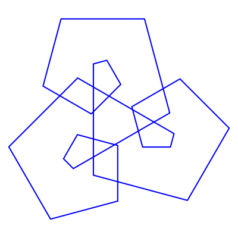

- E:
  - Turn angle = 45
  - Count max = 9

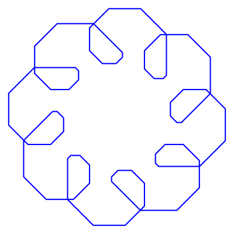

- F:
  - Turn angle = 60
  - Count max = 19

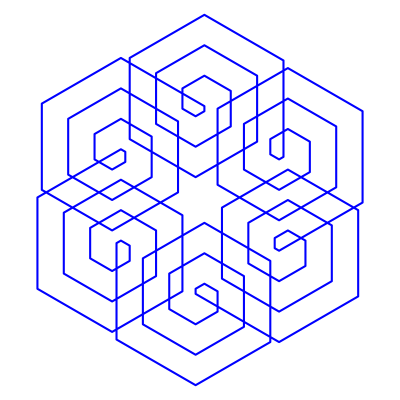

- G:
  - Turn angle = 45
  - Count max = 7

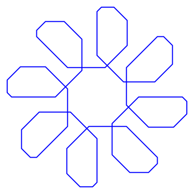

- H:
  - Turn angle = 144
  - Count max = 16

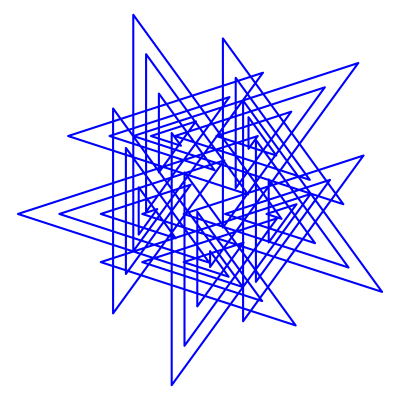

Let's say you want to make a [spirolateral](https://en.wikipedia.org/wiki/Spirolateral).

If the turn angle is $\theta=140^{\circ}$ and the maximum segment length is $n=13$, then which spirolateral is created?

You can use this tool:

https://artockthedino.github.io/pbl/spirolateral/spirolateral_generator.html

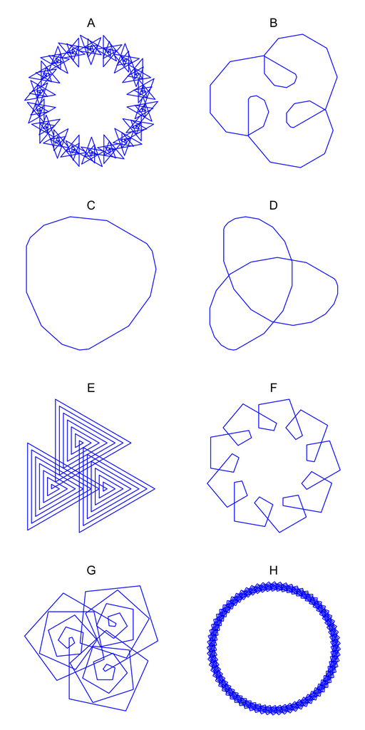

ABCDEFGH

The correct answer is A.

Below I've listed the parameters used to generate all patterns:

- A:
  - Turn angle = 140
  - Count max = 13

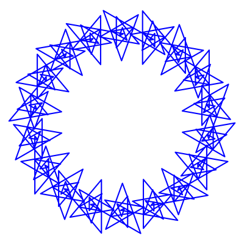

- B:
  - Turn angle = 40
  - Count max = 12

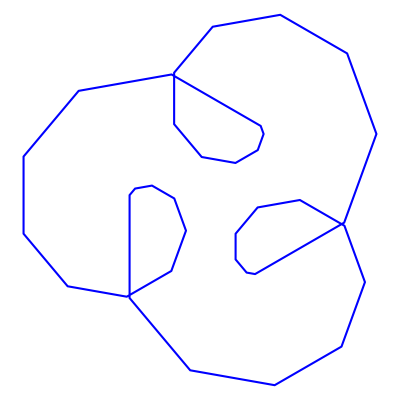

- C:
  - Turn angle = 24
  - Count max = 5

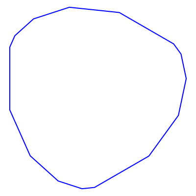

- D:
  - Turn angle = 20
  - Count max = 12

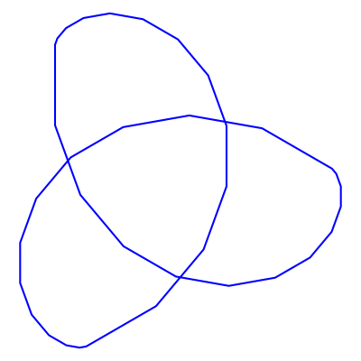

- E:
  - Turn angle = 120
  - Count max = 20

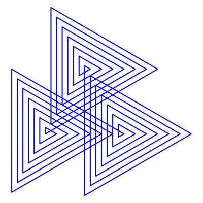

- F:
  - Turn angle = 80
  - Count max = 5

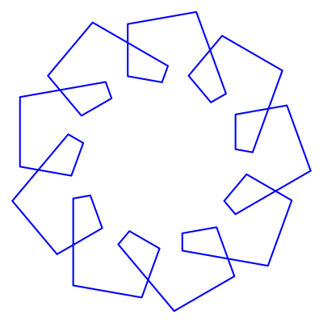

- G:
  - Turn angle = 78
  - Count max = 20

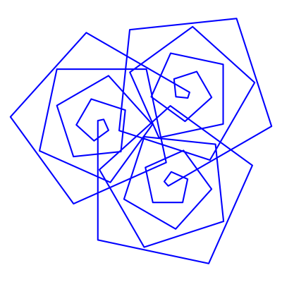

- H:
  - Turn angle = 85
  - Count max = 17

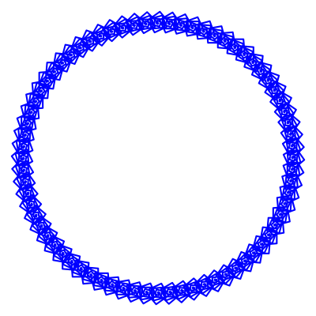

Consider the [L system](https://en.wikipedia.org/wiki/L-system) defined by the following start and replacement rules:

- Start = DD
- Rules:
  - D $\to$ NX
  - N $\to$ NX
  - X $\to$ DX

After 5 iterations, what string is developed? I'd recommend using [this tool](https://chadworley.github.io/Lsys_string_gen.html).

Consider the [L system](https://en.wikipedia.org/wiki/L-system) defined by the following start and replacement rules:

- Start = J
- Rules:
  - D $\to$ ST
  - J $\to$ TDJ
  - S $\to$ SS
  - T $\to$ JJ

After 5 iterations, what string is developed? I'd recommend using [this tool](https://chadworley.github.io/Lsys_string_gen.html).

Consider the [L system](https://en.wikipedia.org/wiki/L-system) defined by the following start and replacement rules:

- Start = SZ
- Rules:
  - A $\to$ GS
  - G $\to$ GZG
  - S $\to$ ASS
  - Z $\to$ AS

After 4 iterations, what string is developed? I'd recommend using [this tool](https://chadworley.github.io/Lsys_string_gen.html).

Consider the [L system](https://en.wikipedia.org/wiki/L-system) defined by the following start and replacement rules:

- Start = QW
- Rules:
  - L $\to$ LQWW
  - Q $\to$ QLL
  - W $\to$ WQQ

After 3 iterations, what string is developed? I'd recommend using [this tool](https://chadworley.github.io/Lsys_string_gen.html).

A turtle starts at the central red dot facing North. It uses the following commands:

- Character `F` means drag pen **Forward**
- Character `+` means turn 90° right (clockwise)
- Character `-` means turn 90° left (counterclockwise)
- Character `X` means hop forward without drawing
- Character `[` means save current position at top of pile
- Character `]` means teleport to saved position (use position at top of pile and remove that position from pile)

Use the following command string:

`F-FFFFFFFF-FFFF[-FF-FF]FFFFF`

Which drawing is correct?

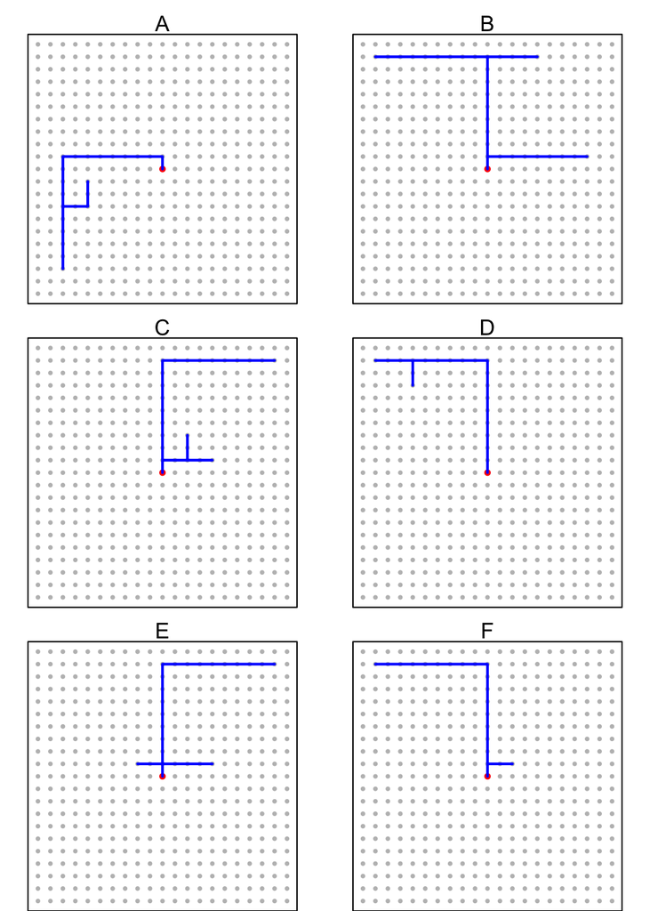

ABCDEF

The correct answer is A.

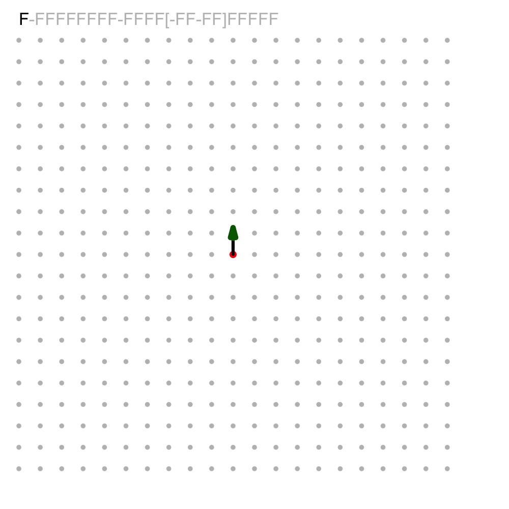

A turtle starts at the central red dot facing North. It uses the following commands:

- Character `F` means drag pen **Forward**
- Character `+` means turn 90° right (clockwise)
- Character `-` means turn 90° left (counterclockwise)
- Character `X` means hop forward without drawing
- Character `[` means save current position at top of pile
- Character `]` means teleport to saved position (use position at top of pile and remove that position from pile)

Use the following command string:

`F[-FFFFFFFF-FF[-FF]FFFFFF]FFFFFFFF+FFFFFFFFF`

Which drawing is correct?

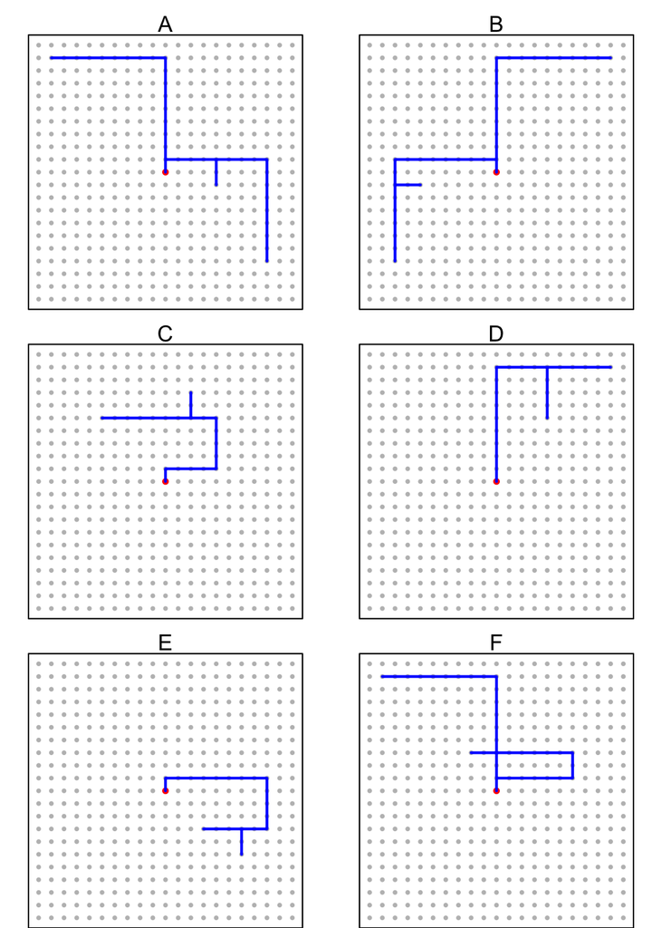

ABCDEF

The correct answer is B.

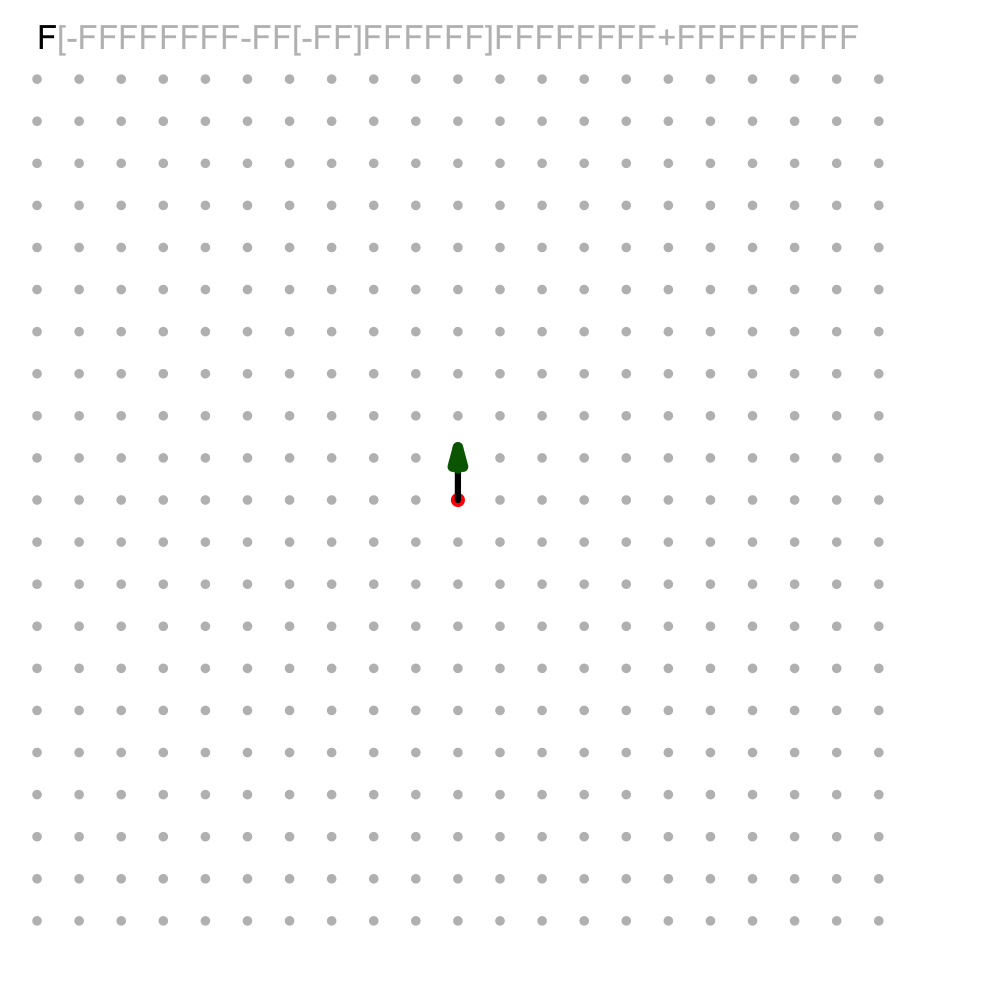

A turtle starts at the central red dot facing North. It uses the following commands:

- Character `F` means drag pen **Forward**
- Character `+` means turn 90° right (clockwise)
- Character `-` means turn 90° left (counterclockwise)
- Character `X` means hop forward without drawing
- Character `[` means save current position at top of pile
- Character `]` means teleport to saved position (use position at top of pile and remove that position from pile)

Use the following command string:

`F[-FFFF-FFFF]FFFFFFFF-FFFFFFFFF`

Which drawing is correct?

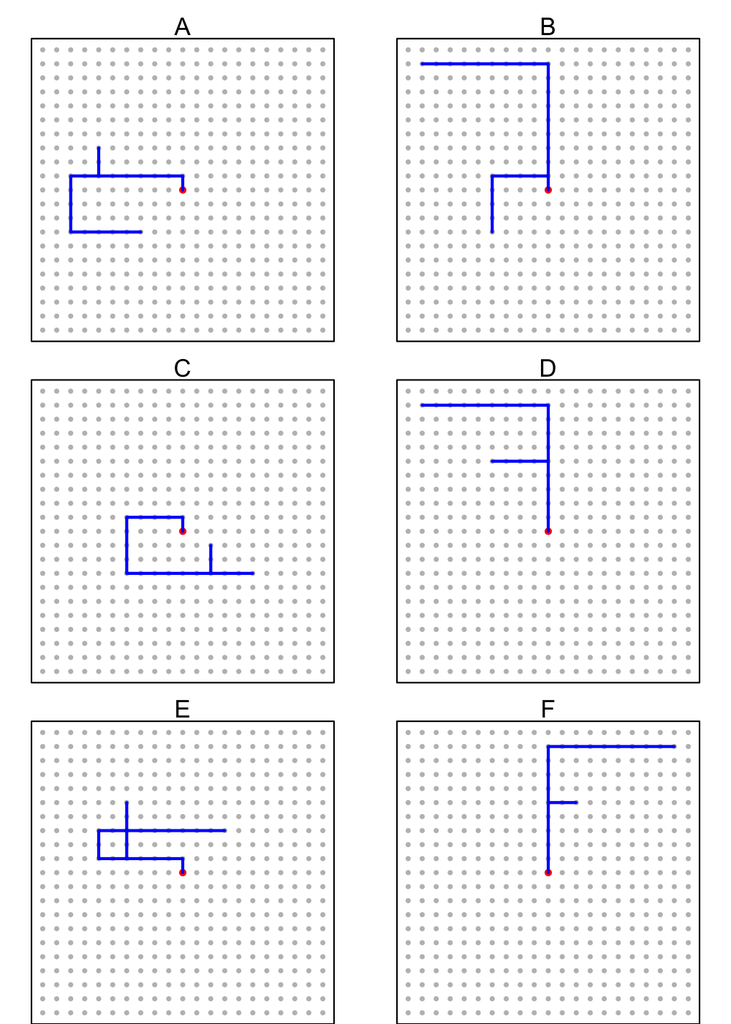

ABCDEF

The correct answer is B.

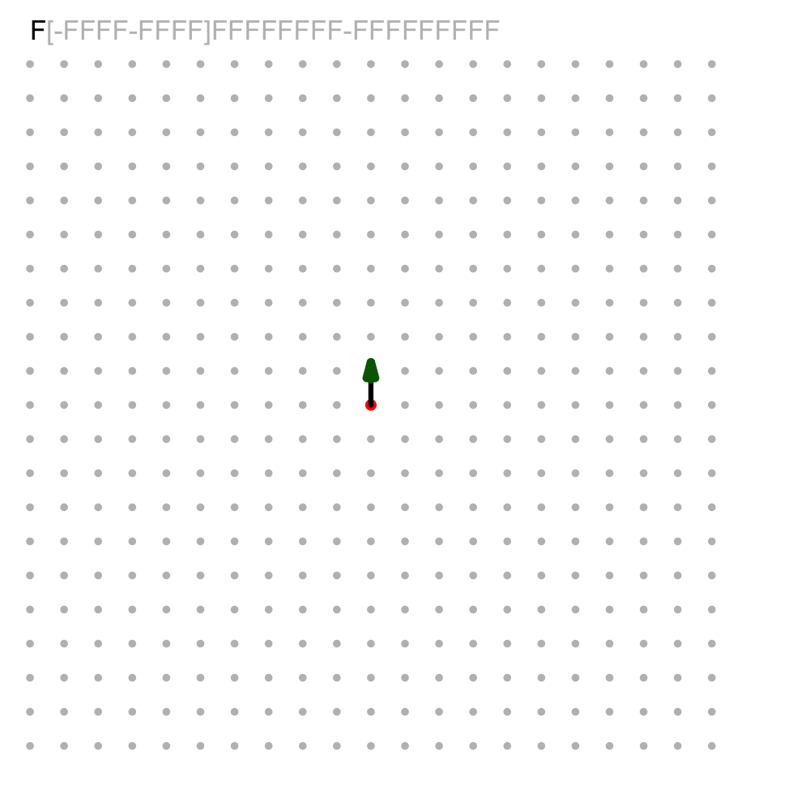

A turtle starts at the central red dot facing North. It uses the following commands:

- Character `F` means drag pen **Forward**
- Character `+` means turn 90° right (clockwise)
- Character `-` means turn 90° left (counterclockwise)
- Character `X` means hop forward without drawing
- Character `[` means save current position at top of pile
- Character `]` means teleport to saved position (use position at top of pile and remove that position from pile)

Use the following command string:

`F[-FFFF]FF[+FF]FFFFFF+FFFFFFFFF`

Which drawing is correct?

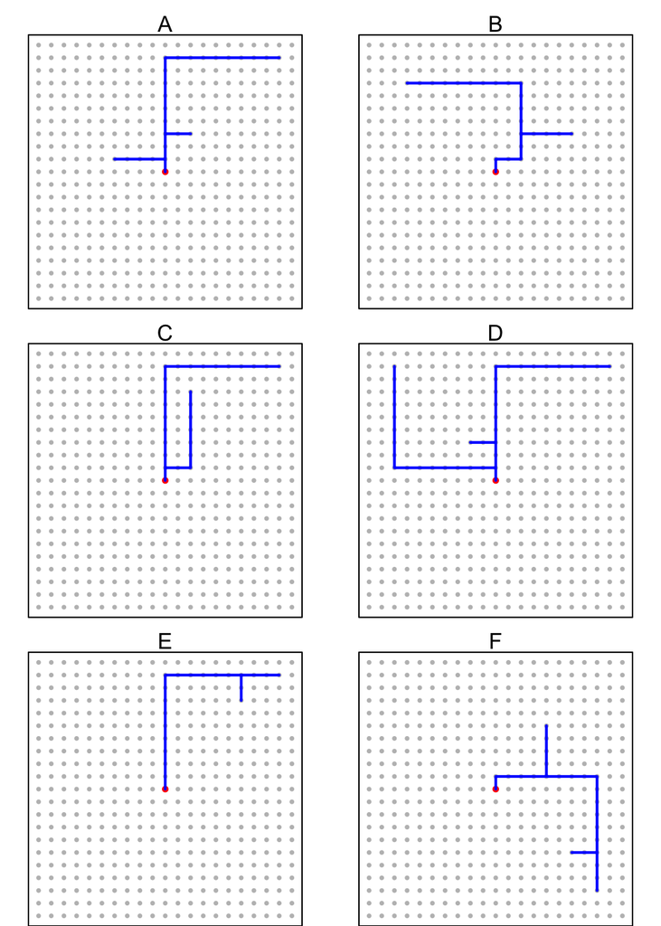

ABCDEF

The correct answer is A.

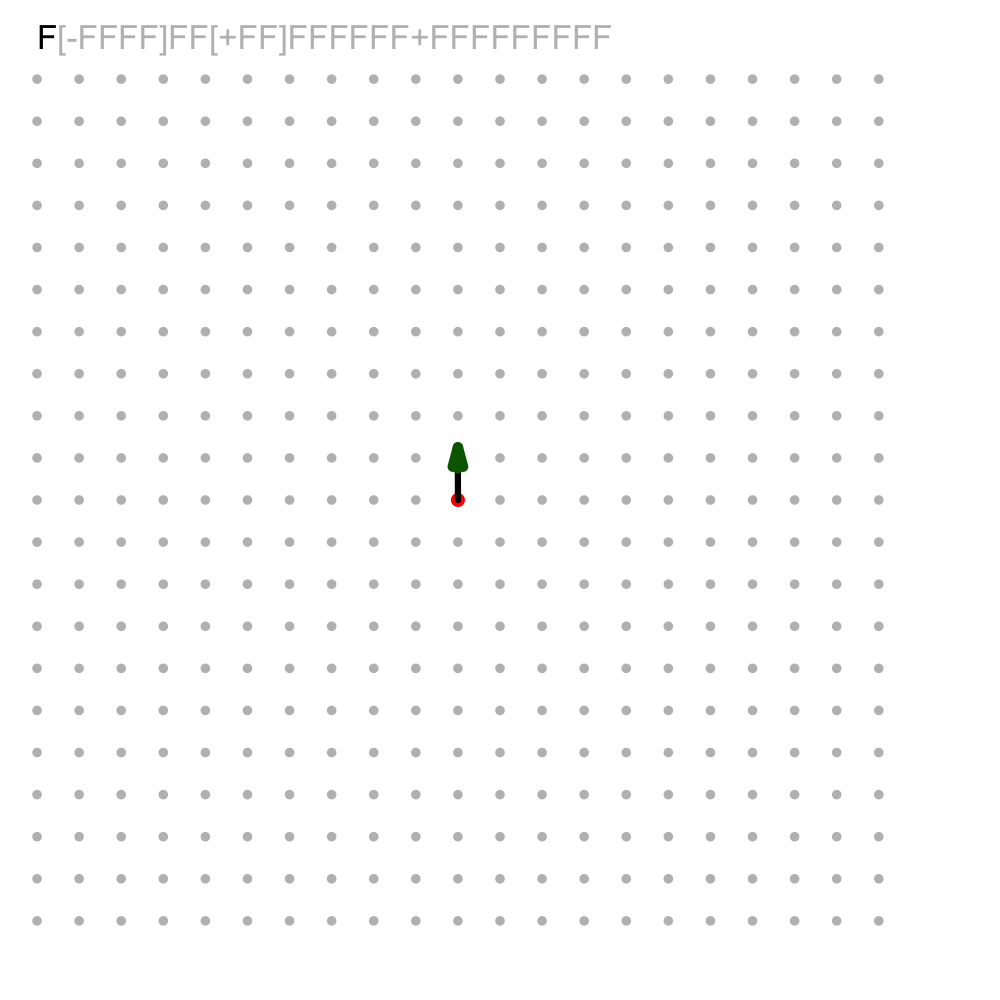

Consider the $L$-system (and turn angle) defined below:

- Start: `A--A--A`
- Rules:  
  `A > A[-A]A`
- Number of recursions (number of iterations):
  - 6
- Turn angle
  - 60°

Please use [this online tool](https://artockthedino.github.io/lsys.html) to generate the pattern using turtle graphics. Choose the matching pattern. (The initial angle should be $270$ degrees to match the orientation.)

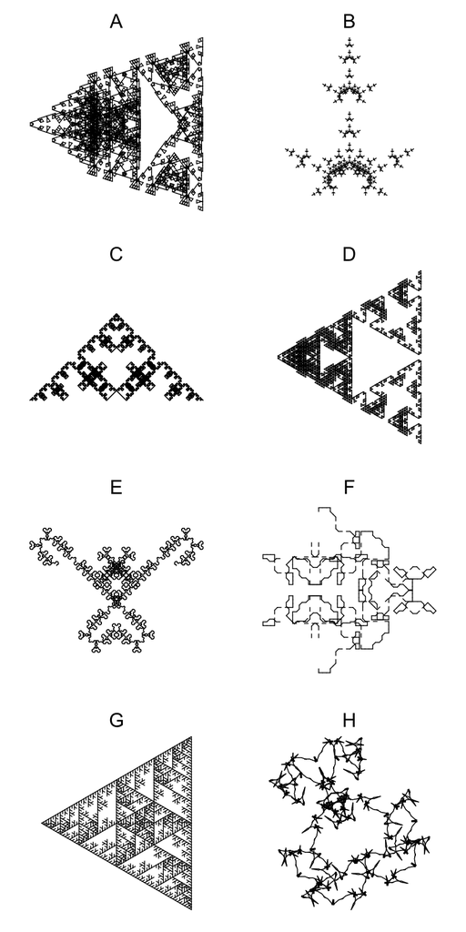

ABCDEFGH

The correct pattern is pattern G.

1. Use the first link: https://artockthedino.github.io/lsys.html
2. Copy/paste the `Axiom`, `Rules`, `Iterations`, and `Turn angle`.
3. Click `Generate Pattern`
4. Back to the quiz, select the matching pattern.

In case you're interested in the parameters of the other patterns shown:

## Pattern A

- Start: `A`
- Rules:  
  `A > B-ABA-B`  
  `B > A+B+A`
- Number of recursions (number of iterations):
  - 6
- Angle
  - 108

## Pattern B

- Start: `A`
- Rules:  
  `A > X[-A][+A]AA`  
  `X > XX`
- Number of recursions (number of iterations):
  - 5
- Angle
  - 60

## Pattern C

- Start: `AA`
- Rules:  
  `A > A++B-C-B++A`  
  `B > B--A+C+A--B`  
  `C > CC`
- Number of recursions (number of iterations):
  - 6
- Angle
  - 45

## Pattern D

- Start: `A`
- Rules:  
  `A > B-ABA-B`  
  `B > A+B+A`
- Number of recursions (number of iterations):
  - 6
- Angle
  - 120

## Pattern E

- Start: `AA`
- Rules:  
  `A > B-AA-B`  
  `B > A+B+A`
- Number of recursions (number of iterations):
  - 6
- Angle
  - 45

## Pattern F

- Start: `A`
- Rules:  
  `A > AXB+C+BXA`  
  `B > C--BAB--C`  
  `C > B+D-A-D+B`  
  `X > XX`  
  `D > DD`
- Number of recursions (number of iterations):
  - 4
- Angle
  - 45

## Pattern G

- Start: `A--A--A`
- Rules:  
  `A > A[-A]A`
- Number of recursions (number of iterations):
  - 6
- Angle
  - 60

## Pattern H

- Start: `A`
- Rules:  
  `A > C--ABA--C`  
  `B > BA+C+AB`  
  `C > -BCA+ACB-`
- Number of recursions (number of iterations):
  - 5
- Angle
  - 170

Consider the $L$-system (and turn angle) defined below:

- Start: `A`
- Rules:  
  `A > [---B][-B][+B][+++B]`  
  `B > BD[++DA][--DA]B`  
  `D > DD`
- Number of recursions (number of iterations):
  - 5
- Turn angle
  - 45°

Please use [this online tool](https://artockthedino.github.io/lsys.html) to generate the pattern using turtle graphics. Choose the matching pattern. (The initial angle should be $270$ degrees to match the orientation.)

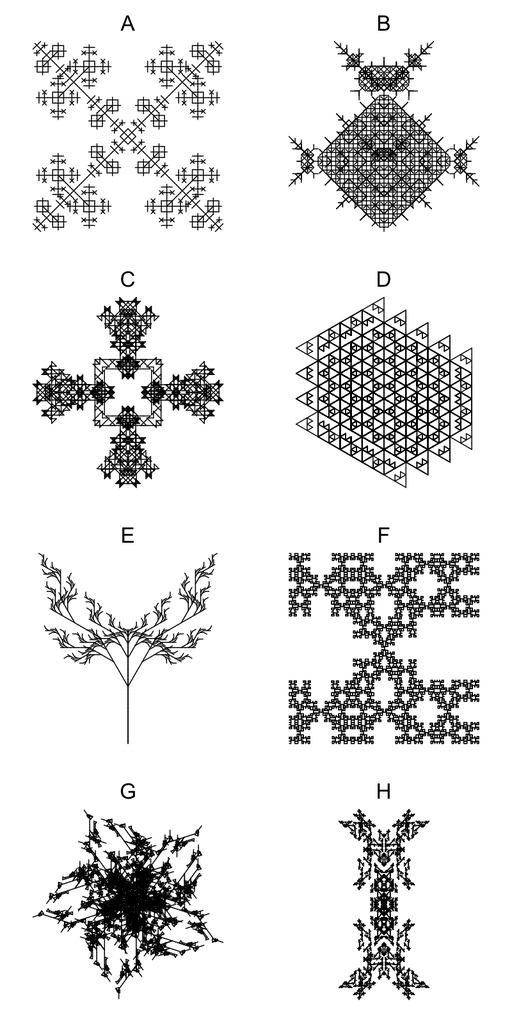

ABCDEFGH

The correct pattern is pattern A.

1. Use the first link: https://artockthedino.github.io/lsys.html
2. Copy/paste the `Axiom`, `Rules`, `Iterations`, and `Turn angle`.
3. Click `Generate Pattern`
4. Back to the quiz, select the matching pattern.

In case you're interested in the parameters of the other patterns shown:

## Pattern A

- Start: `A`
- Rules:  
  `A > [---B][-B][+B][+++B]`  
  `B > BD[++DA][--DA]B`  
  `D > DD`
- Number of recursions (number of iterations):
  - 5
- Angle
  - 45

## Pattern B

- Start: `A`
- Rules:  
  `A > A[++A][--A]A[+B][-B]`  
  `B > A[----B][++++B]B`
- Number of recursions (number of iterations):
  - 5
- Angle
  - 45

## Pattern C

- Start: `A++A++A++A`
- Rules:  
  `A > B-ABA-B`  
  `B > A+BB+A`
- Number of recursions (number of iterations):
  - 4
- Angle
  - 135

## Pattern D

- Start: `A`
- Rules:  
  `A > +AA-B--A--B-AA+`  
  `B > -BB+A++B++A+BB-`
- Number of recursions (number of iterations):
  - 5
- Angle
  - 120

## Pattern E

- Start: `[A][B]`
- Rules:  
  `A > C[-A-B]A`  
  `B > C[+B+A]B`  
  `C > CC`
- Number of recursions (number of iterations):
  - 5
- Angle
  - 30

## Pattern F

- Start: `A`
- Rules:  
  `A > +BB-ABA-BB+`  
  `B > -AA+BAB+AA-`
- Number of recursions (number of iterations):
  - 5
- Angle
  - 90

## Pattern G

- Start: `AAAAA`
- Rules:  
  `A > A+B+A`  
  `B > CC-[+CA][-CA]-B`  
  `C > CC`
- Number of recursions (number of iterations):
  - 6
- Angle
  - 108

## Pattern H

- Start: `A++++A`
- Rules:  
  `A > +B-AXBBXA-B+`  
  `B > -A+BXAXB+A-`  
  `X > XX`
- Number of recursions (number of iterations):
  - 5
- Angle
  - 135

Consider the $L$-system (and turn angle) defined below:

- Start: `A`
- Rules:  
  `A > ADB+D+BDA`  
  `B > C-DAD-C`  
  `C > B+A-D-A+B`  
  `D > DD`
- Number of recursions (number of iterations):
  - 5
- Turn angle
  - 60°

Please use [this online tool](https://artockthedino.github.io/lsys.html) to generate the pattern using turtle graphics. Choose the matching pattern. (The initial angle should be $270$ degrees to match the orientation.)

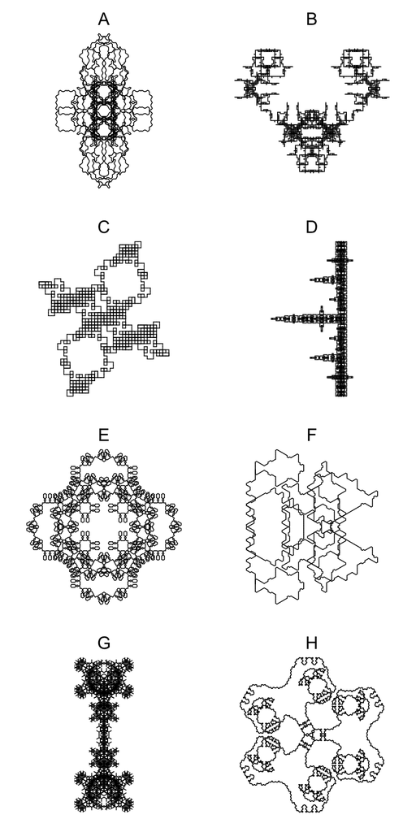

ABCDEFGH

The correct pattern is pattern F.

1. Use the first link: https://artockthedino.github.io/lsys.html
2. Copy/paste the `Axiom`, `Rules`, `Iterations`, and `Turn angle`.
3. Click `Generate Pattern`
4. Back to the quiz, select the matching pattern.

In case you're interested in the parameters of the other patterns shown:

## Pattern A

- Start: `AA`
- Rules:  
  `A > C--AA+B+AA--C`  
  `B > BA+C+AB`  
  `C > -B-CA++AC-B-`
- Number of recursions (number of iterations):
  - 4
- Angle
  - 30

## Pattern B

- Start: `-A`
- Rules:  
  `A > +BA+A-ABA-A+AB+`  
  `B > +BBA-B--B-ABB+`
- Number of recursions (number of iterations):
  - 4
- Angle
  - 90

## Pattern C

- Start: `AA`
- Rules:  
  `A > B-AA-B`  
  `B > AB+B+A`
- Number of recursions (number of iterations):
  - 5
- Angle
  - 90

## Pattern D

- Start: `A`
- Rules:  
  `A > B-ABA-B`  
  `B > A+B+A`
- Number of recursions (number of iterations):
  - 6
- Angle
  - 90

## Pattern E

- Start: `A+++A+++A+++A`
- Rules:  
  `A > B--B`  
  `B > AA+++AA`
- Number of recursions (number of iterations):
  - 7
- Angle
  - 30

## Pattern F

- Start: `A`
- Rules:  
  `A > ADB+D+BDA`  
  `B > C-DAD-C`  
  `C > B+A-D-A+B`  
  `D > DD`
- Number of recursions (number of iterations):
  - 5
- Angle
  - 60

## Pattern G

- Start: `A+++XA`
- Rules:  
  `A > AA[-B][+B]B`  
  `B > [--ABC][++ABC]`  
  `C > A[-CB][+CB]`  
  `X > XX`
- Number of recursions (number of iterations):
  - 5
- Angle
  - 60

## Pattern H

- Start: `AAA`
- Rules:  
  `A > C--AA++B++AA--C`  
  `B > BA+C+AB`  
  `C > -B-CA++AC-B-`
- Number of recursions (number of iterations):
  - 4
- Angle
  - 30

Consider the $L$-system (and turn angle) defined below:

- Start: `A`
- Rules:  
  `A > A--ACB+C+BCA--A`  
  `B > BA+++C+++AB`  
  `C > -B--A+C+A--B-`
- Number of recursions (number of iterations):
  - 4
- Turn angle
  - 30°

Please use [this online tool](https://artockthedino.github.io/lsys.html) to generate the pattern using turtle graphics. Choose the matching pattern. (The initial angle should be $270$ degrees to match the orientation.)

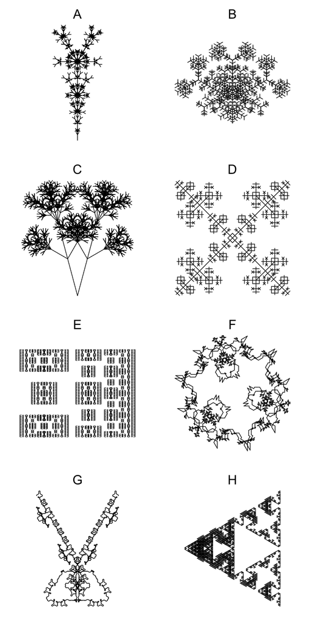

ABCDEFGH

The correct pattern is pattern G.

1. Use the first link: https://artockthedino.github.io/lsys.html
2. Copy/paste the `Axiom`, `Rules`, `Iterations`, and `Turn angle`.
3. Click `Generate Pattern`
4. Back to the quiz, select the matching pattern.

In case you're interested in the parameters of the other patterns shown:

## Pattern A

- Start: `A`
- Rules:  
  `A > ADB`  
  `B > [-CA][+CA]`  
  `C > [+C[-A][+A]][-C[-A][+A]]`  
  `D > E`  
  `E > AA`
- Number of recursions (number of iterations):
  - 7
- Angle
  - 30

## Pattern B

- Start: `A`
- Rules:  
  `A > A[-BC][+BC]BC`  
  `B > BB[-ABC][+ABC]`  
  `C > CCC[-CBA][+CBA]`
- Number of recursions (number of iterations):
  - 4
- Angle
  - 60

## Pattern C

- Start: `C`
- Rules:  
  `A > F[---BC][+++BC]`  
  `B > F[-CA][+CA]`  
  `C > [-AB][+AB]`  
  `F > FF`
- Number of recursions (number of iterations):
  - 6
- Angle
  - 15

## Pattern D

- Start: `A`
- Rules:  
  `A > [---B][-B][+B][+++B]`  
  `B > BD[++DA][--DA]B`  
  `D > DD`
- Number of recursions (number of iterations):
  - 5
- Angle
  - 45

## Pattern E

- Start: `A`
- Rules:  
  `A > +BX-AA-XB+`  
  `B > -AX+B+XA-`  
  `X > XX`
- Number of recursions (number of iterations):
  - 7
- Angle
  - 90

## Pattern F

- Start: `A-A-A`
- Rules:  
  `A > C--ABA--C`  
  `B > BA+C+AB`  
  `C > -BCA+ACB-`
- Number of recursions (number of iterations):
  - 4
- Angle
  - 150

## Pattern G

- Start: `A`
- Rules:  
  `A > A--ACB+C+BCA--A`  
  `B > BA+++C+++AB`  
  `C > -B--A+C+A--B-`
- Number of recursions (number of iterations):
  - 4
- Angle
  - 30

## Pattern H

- Start: `A`
- Rules:  
  `A > B-ABA-B`  
  `B > A+B+A`
- Number of recursions (number of iterations):
  - 6
- Angle
  - 120